# Homework 5

# Submission Instructions

- Submit responses in a .ipynb file.
- For calculation questions:
  - Include R code used.
  - Ensure all code has been executed to display output.
  - Round *answers* to 3-5 decimal places if necessary.
  - Avoid unnecessary R outputs.
  - Support conclusions with plots when checking assumptions.
  - Assume $\alpha = 0.05$ and set any trimming to $20\%$ unless stated otherwise.
  - Do not use robust methods unless specified by the question.
  - Two-sided hypothesis tests require two-sided confidence intervals.
  - One-sided hypothesis tests require one-sided confidence intervals.

# Question 1

To investigate the question “*do sexual images in advertisements affect people’s ability to remember the item being advertised*”, a group of statistics students cut ads out of magazines. They were careful to find two ads for each of 10 similar items, one with a sexual image and one without. They arranged the ads in a random order and had 39 subjects look at them for 1 minute. They then asked the subjects to list as many of the products as they could remember. Their data can be found in the file **sexSells.csv**.

Notice that the data is in the tidy format but it is not in a logical order. This is a common problem with datasets. Find a way to *order* the data by the ‘Image’ and ‘Subject’ columns (below is an example of the first 10 rows ordered appropriately). Display the ordered dataset’s full output.

Hint: no special packages are required for this and a basic internet search should give you the solution you desire.

```
## # A tibble: 10 × 3
##    Subject AdRecall Image
##      <dbl>    <dbl> <chr>
##  1       1        2 NotSexy
##  2       2        7 NotSexy
##  3       3        1 NotSexy
##  4       4        5 NotSexy
##  5       5        0 NotSexy
##  6       6        3 NotSexy
##  7       7        5 NotSexy
##  8       8        4 NotSexy
##  9       9        7 NotSexy
## 10      10        4 NotSexy
```

Using Base-R functions…

```r
# Load Disorganized Data
ad_data <- read_csv("../Data/sexSells.csv")

# Use the 'order' function inside your row index
ad_data <- ad_data[order(ad_data$Image, ad_data$Subject), ]

ad_data
```

```
## # A tibble: 78 × 3
##    Subject AdRecall Image
##      <dbl>    <dbl> <chr>
##  1       1        2 NotSexy
##  2       2        7 NotSexy
##  3       3        1 NotSexy
##  4       4        5 NotSexy
##  5       5        0 NotSexy
##  6       6        3 NotSexy
##  7       7        5 NotSexy
##  8       8        4 NotSexy
##  9       9        7 NotSexy
## 10      10        4 NotSexy
## # ℹ 68 more rows
```

If you want to stay in the tidyverse …

```r
# Pipe the data into the arrange() function
ad_data <- read_csv("../Data/sexSells.csv") |>
  arrange(Image, Subject)

ad_data
```

```
## # A tibble: 78 × 3
##    Subject AdRecall Image
##      <dbl>    <dbl> <chr>
##  1       1        2 NotSexy
##  2       2        7 NotSexy
##  3       3        1 NotSexy
##  4       4        5 NotSexy
##  5       5        0 NotSexy
##  6       6        3 NotSexy
##  7       7        5 NotSexy
##  8       8        4 NotSexy
##  9       9        7 NotSexy
## 10      10        4 NotSexy
## # ℹ 68 more rows
```

# Question 2

Using $\alpha = 0.05$, assume the data come from a normally distributed population and test the hypothesis that sexual ads are remembered **better** than the nonsexual ads. i.e., $H_0: \mu_{\text{sexy}} - \mu_{\text{notSexy}} > 0$. Use of `t.test()` is not permitted.

Make sure to report:

- the test statistic
- the degrees of freedom
- p-value
- Confidence Interval
- Whether you reject or fail to reject $H_0$

```r
#Calculate Difference Scores
diff_scores <- ad_data$AdRecall[ad_data$Image == "Sexy"] -
  ad_data$AdRecall[ad_data$Image == "NotSexy"]

#Summary Stats
N <- length(diff_scores)
m <- mean(diff_scores)
mu <- 0
se <- sd(diff_scores)/sqrt(N)

#Test Statistic
t <- (m - mu)/se

# Degrees of Freedom
df <- N - 1

# p-val
#H0: sexy > nonSexy
# i.e., sexy - nonSexy > 0
p <- pt(t, df = df)

# Confidence interval
alpha <- 0.05
t_crit <- abs(qt(alpha, df = df))

low_ci <- -Inf
top_ci <- m + t_crit * se
```

```
## T = 0.859
```

```
## df = 38
```

```
## p = 0.802
```

```
## [1] "95% CI = (-Inf, 0.6836]"
```

> We FAIL to reject the null hypothesis that $H_0: \mu_{\text{sexy}} - \mu_{\text{notSexy}} > 0$.

# Question 3

Calculate an appropriate effect size for question 2. What is this effect size telling us? Use of `cohen.d()` is not permitted.

```r
# Correlation
R <- cor(
  ad_data$AdRecall[ad_data$Image == "Sexy"],
  ad_data$AdRecall[ad_data$Image == "NotSexy"]
) # Note that the data needs to be in a logical order for this to give the correct result.

s_rm <- sd(diff_scores) / sqrt(2*(1 - R))

d <- mean(diff_scores) / s_rm

# Check number of pairs
length(ad_data$AdRecall[ad_data$Image == "Sexy"])
```

```
## [1] 39
```

```r
#Since there are less than 50 pairs, we will use Hedge's g.
g <- d * (1 - (3 / (4*(df)-1)))
g
```

```
## [1] 0.1314418
```

> There is a small difference of 0.131 standard deviations between the recall of the two types of ads.

# Question 4

What are the independent and dependent variables in the **sexSells.csv** study?

- *Dependent Variable:* Ad recall
- *Independent Variable:* Image in the ad (i.e., Sexy vs. Not Sexy)

# Question 5

Plot a bar graph showing the means of both groups and their difference. Give each bar an errorbar that corresponds to a two-sided 95% confidence interval around the mean.

```r
#Add difference scores to the dataframe
Subject <- 1:39
AdRecall <- diff_scores #from earlier question
Image <- c(rep("Difference", 39))
diff_data <- data.frame(Subject, AdRecall, Image)
ad_data_diff <- rbind(ad_data, diff_data)
```

```r
# Obtain values for plot
plot_data <- ad_data_diff %>%
  group_by(Image) %>%
  summarise(
    n = length(AdRecall),
    m = mean(AdRecall),
    se = sd(AdRecall) / sqrt(n),
    df = n - 1,
    alpha = 0.05,
    t_crit = abs(qt(alpha / 2, df)),
    moe = se * t_crit,
    lower = m - t_crit,
    upper = m + t_crit
  )
```

```r
# Factoring data to put bars in a sensible order
plot_data$Image <- factor(plot_data$Image,
  levels = c("Sexy", "NotSexy", "Difference")
)
```

```r
# For reference, here are the plotting values
plot_data
```

```
## # A tibble: 3 × 10
##   Image          n      m     se    df alpha t_crit    moe  lower upper
##   <fct>      <int>  <dbl>  <dbl> <dbl> <dbl>  <dbl>  <dbl>  <dbl> <dbl>
## 1 Difference    39 0.2308 0.2686    38  0.05  2.024 0.5438 -1.794 2.255
## 2 NotSexy       39 3.538  0.2671    38  0.05  2.024 0.5406  1.514 5.563
## 3 Sexy          39 3.769  0.2833    38  0.05  2.024 0.5735  1.745 5.794
```

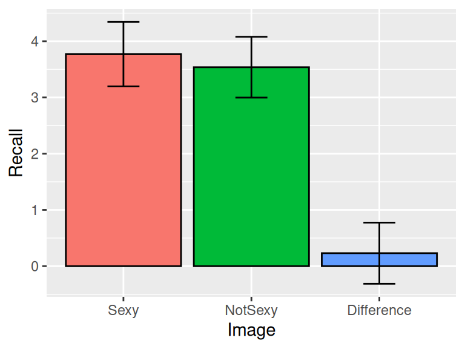

```r
# Plot the Data
ggplot(plot_data, aes(x = Image, y = m, fill = Image)) +
  geom_bar(stat = "identity", colour = "black") +
  geom_errorbar(
    aes(ymin = m - moe, ymax = m + moe),
    width = .25
  ) +
  ylab("Recall") +
  theme(legend.position = "none")
```

# Question 6

Use a Q-Q plot to assess the normality of the **sexSells.csv** data. Why do you think the plot looks so strange? (You won’t loose marks if your are incorrect).

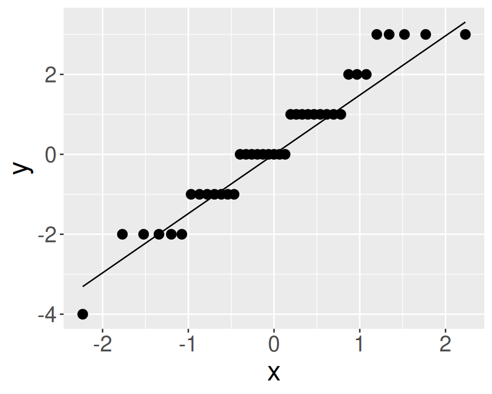

```r
ggplot(mapping = aes(sample = diff_scores)) +
  stat_qq(size = 3) +
  stat_qq_line() +
  theme(text = element_text(size = 20))
```

> It looks strange because there are numerous repetitions of the same value. If you examine the difference scores you will find five -2’s, seven -1’s, nine 0’s and so on. It’s worth considering how you might prevent this when designing your own studies.

# Question 7

Repeat question 2 using 20% trimmed means.

```r
library(WRS2)

N <- length(diff_scores)
mu <- 0
G <- 0.2
m <- mean(diff_scores, tr = G)
var <- winvar(diff_scores, tr = G)
s <- sqrt(var)
se <- s / ((1 - 2 * G) * sqrt(N))

# Degrees of Freedom
h <- N - 2 * floor(G * N)
df <- h - 1

# Test Statistic
t <- (m - mu) / se

# p-val
# H0: sexy > nonSexy
# i.e., sexy - nonSexy > 0
p <- pt(t, df = df)

# Confidence interval
alpha <- 0.05
t_crit <- abs(qt(alpha, df = df))

low_ci <- -Inf
top_ci <- m + t_crit * se
```

```
## T = 0.651
```

```
## df = 24
```

```
## p = 0.739
```

```
## [1] "95% CI = (-Inf, 0.7254]"
```

> We fail to reject the null hypothesis that $H_0: Sexy - NotSexy > 0$.